# Provisioning Rate Repeatability

# Repeatability analysis ————————————

```r
rep.Prov.rate <- (Prov_rate_MCMC_model1$VCV[, "BirdID"])/ (Prov_rate_MCMC_model1$VCV[, "BirdID"]+ Prov_rate_MCMC_model1$VCV[,"NestID:NWID"] + Prov_rate_MCMC_model1$VCV[,"Observer"] + Prov_rate_MCMC_model1$VCV[,"units"]+log(1/exp(Prov_rate_MCMC_model1$Sol[,"(Intercept)"])+1))

posterior.mode(rep.Prov.rate)
```

```
##      var1
## 0.1003711
```

```r
HPDinterval(rep.Prov.rate)
```

```
##           lower     upper
## var1 0.05700561 0.1576663
## attr(,"Probability")
## [1] 0.95
```

# Running Non-Bayesian models ——————————-

Run same model in lme4 to see if the prior is suitable and produces similar variances for the fixed effects Should give similar repeatability score

```r
Prov_Rate_glmer_model1 <- glmer(ProvFeedsPerHour ~ HelperNo + Sex + GroupSize + BroodSize + Age_centred + TQ_centred + (1|BirdID) + (1|NestID) + (1|NestID:NWID) + (1|Observer), family = poisson, data = Prov.rate)
summary(Prov_Rate_glmer_model1) #model does not converge
```

```
## Generalized linear mixed model fit by maximum likelihood (Laplace
##   Approximation) [glmerMod]
##  Family: poisson  ( log )
## Formula:
## ProvFeedsPerHour ~ HelperNo + Sex + GroupSize + BroodSize + Age_centred +
##     TQ_centred + (1 | BirdID) + (1 | NestID) + (1 | NestID:NWID) +
##     (1 | Observer)
##    Data: Prov.rate
##
##      AIC      BIC   logLik deviance df.resid
##   7535.2   7592.7  -3756.6   7513.2     1368
##
## Scaled residuals:
##     Min      1Q  Median      3Q     Max
## -2.2772 -0.6714 -0.0535  0.5224  3.4263
##
## Random effects:
##  Groups      Name        Variance Std.Dev.
##  NestID:NWID (Intercept) 0.04788  0.2188
##  BirdID      (Intercept) 0.04267  0.2066
##  NestID      (Intercept) 0.02795  0.1672
##  Observer    (Intercept) 0.03036  0.1742
## Number of obs: 1379, groups:
## NestID:NWID, 716; BirdID, 554; NestID, 513; Observer, 40
##
## Fixed effects:
##             Estimate Std. Error z value Pr(>|z|)
## (Intercept)  1.74379    0.10259  16.997  < 2e-16 ***
## HelperNo    -0.10189    0.03475  -2.932  0.00336 **
## Sex1        -0.02220    0.02799  -0.793  0.42764
## GroupSize    0.02037    0.02846   0.716  0.47425
## BroodSize    0.16960    0.05417   3.131  0.00174 **
## Age_centred -0.12346    0.03050  -4.047 5.18e-05 ***
## TQ_centred   0.03705    0.03821   0.970  0.33225
## ---
## Signif. codes:  0 '***' 0.001 '**' 0.01 '*' 0.05 '.' 0.1 ' ' 1
##
## Correlation of Fixed Effects:
##             (Intr) HelprN Sex1   GropSz BrodSz Ag_cnt
## HelperNo     0.410
## Sex1        -0.134 -0.005
## GroupSize   -0.722 -0.657  0.002
## BroodSize   -0.585 -0.119 -0.001  0.044
## Age_centred  0.008 -0.038  0.025 -0.021  0.038
## TQ_centred  -0.039  0.004  0.010  0.054 -0.014  0.047
## convergence code: 0
## Model failed to converge with max|grad| = 0.0584699 (tol = 0.002, component 1)
```

The model does not converge Increase the number of iterations as outlined in https://rstudio-pubs-static.s3.amazonaws.com/33653_57fc7b8e5d484c909b615d8633c01d51.html

```r
ss <- getME(Prov_Rate_glmer_model1, c("theta", "fixef"))
Prov_Rate_glmer_model2 <- update(Prov_Rate_glmer_model1, start = ss, control = glmerControl(optCtrl = list(maxfun=2e4)))

summary(Prov_Rate_glmer_model2) #model now converges
```

```
## Generalized linear mixed model fit by maximum likelihood (Laplace
##   Approximation) [glmerMod]
##  Family: poisson  ( log )
## Formula:
## ProvFeedsPerHour ~ HelperNo + Sex + GroupSize + BroodSize + Age_centred +
##     TQ_centred + (1 | BirdID) + (1 | NestID) + (1 | NestID:NWID) +
##     (1 | Observer)
##    Data: Prov.rate
## Control: glmerControl(optCtrl = list(maxfun = 20000))
##
##      AIC      BIC   logLik deviance df.resid
##   7535.2   7592.7  -3756.6   7513.2     1368
##
## Scaled residuals:
##     Min      1Q  Median      3Q     Max
## -2.2773 -0.6714 -0.0533  0.5225  3.4265
##
## Random effects:
##  Groups      Name        Variance Std.Dev.
##  NestID:NWID (Intercept) 0.04780  0.2186
##  BirdID      (Intercept) 0.04268  0.2066
##  NestID      (Intercept) 0.02800  0.1673
##  Observer    (Intercept) 0.03041  0.1744
## Number of obs: 1379, groups:
## NestID:NWID, 716; BirdID, 554; NestID, 513; Observer, 40
##
## Fixed effects:
##             Estimate Std. Error z value Pr(>|z|)
## (Intercept)  1.74371    0.10260  16.995  < 2e-16 ***
## HelperNo    -0.10190    0.03475  -2.933  0.00336 **
## Sex1        -0.02216    0.02799  -0.792  0.42849
## GroupSize    0.02034    0.02846   0.715  0.47476
## BroodSize    0.16953    0.05417   3.129  0.00175 **
## Age_centred -0.12340    0.03050  -4.045 5.23e-05 ***
## TQ_centred   0.03677    0.03821   0.962  0.33596
## ---
## Signif. codes:  0 '***' 0.001 '**' 0.01 '*' 0.05 '.' 0.1 ' ' 1
##
## Correlation of Fixed Effects:
##             (Intr) HelprN Sex1   GropSz BrodSz Ag_cnt
## HelperNo     0.410
## Sex1        -0.134 -0.005
## GroupSize   -0.722 -0.657  0.002
## BroodSize   -0.585 -0.119 -0.001  0.044
## Age_centred  0.008 -0.038  0.025 -0.021  0.038
## TQ_centred  -0.039  0.004  0.010  0.054 -0.014  0.047
```

Extract variance components Variance components are similar but not the same as those produced by MCMCglmm

```r
variance_components <- get_variance(Prov_Rate_glmer_model2)
variance_components
```

```
## $var.fixed
## [1] 0.01088465
##
## $var.random
## [1] 0.1488858
##
## $var.residual
## [1] 0.1375046
##
## $var.distribution
## [1] 0.1375046
##
## $var.dispersion
## [1] 0
##
## $var.intercept
## NestID:NWID      BirdID      NestID    Observer
##  0.04780115  0.04268230  0.02799517  0.03040716
```

Get repeatability score of provisioning rate from glmer Must extract fixed effects so can use intercept estimate Then calculate repeatability as done previously Repeatability score of 0.0954

```r
glmer_fixed <- as.numeric(fixef(Prov_Rate_glmer_model2))
FE_names <- c("Intercept", "HelperNo", "Sex", "GroupSize", "BroodSize", "Age", "TQ")
glmer_fixed_estimates <- tibble(glmer_fixed, FE_names) %>%
  filter(FE_names == "Intercept")

glmer_repeatability <- (variance_components$var.intercept["BirdID"])/(variance_components$var.random + variance_components$var.residual + log(1/exp(glmer_fixed_estimates$glmer_fixed)+1))


glmer_repeatability #similar to that produced by MCMCglmm
```

```
##     BirdID
## 0.09536929
```

```r
rptPoisson(ProvFeedsPerHour ~ HelperNo + Sex + GroupSize + BroodSize + Age_centred + TQ_centred + (1|BirdID) + (1|NestID) + (1|NestID:NWID) + (1|Observer), grname = "BirdID", data = Prov.rate, nboot = 0, npermut = 0)
```

```
##
##
## Repeatability estimation using the glmm method and log link
##
## Repeatability for BirdID
## --------------------------------
## Link-scale approximation:
## R  = 0.109
## SE = NA
## CI = [NA, NA]
## P  = 5.24e-07 [LRT]
##      NA [Permutation]
##
## Original-scale approximation:
## R  = 0.103
## SE = NA
## CI = [NA, NA]
## P  = 5.24e-07 [LRT]
##      NA [Permutation]
```

# Plotting fixed effects ———————————–

Must extract posterior modes and HPD intervals from MCMCglmm model Change names and reorder variables so it is displayed nicer

```r
FixedEffects <- data.frame(posterior.mode(Prov_rate_MCMC_model1$Sol), HPDinterval(Prov_rate_MCMC_model1$Sol))
FixedEffects <- tibble::rownames_to_column(FixedEffects, "term")
FixedEffects <- rename(FixedEffects, estimate = posterior.mode.Prov_rate_MCMC_model1.Sol.)

FixedEffects$term[FixedEffects$term == "HelperNo"] <- "Number of Helpers*"
FixedEffects$term[FixedEffects$term == "Sex1"] <- "Male"
FixedEffects$term[FixedEffects$term == "GroupSize"] <- "Group Size"
FixedEffects$term[FixedEffects$term == "BroodSize"] <- "Brood Size*"
FixedEffects$term[FixedEffects$term == "TQ_centred"] <- "Territory Quality"
FixedEffects$term[FixedEffects$term == "Age_centred"] <- "Age*"

FixedEffects$estimate <- as.numeric(FixedEffects$estimate)
FixedEffects$lower <- as.numeric(FixedEffects$lower)
FixedEffects$upper <- as.numeric(FixedEffects$upper)

FixedEffects$term <- factor(FixedEffects$term, level = c('(Intercept)', 'Number of Helpers*', 'Male', 'Group Size', 'Brood Size*', 'Age*', 'Territory Quality'))
```

Plot Fixed effects

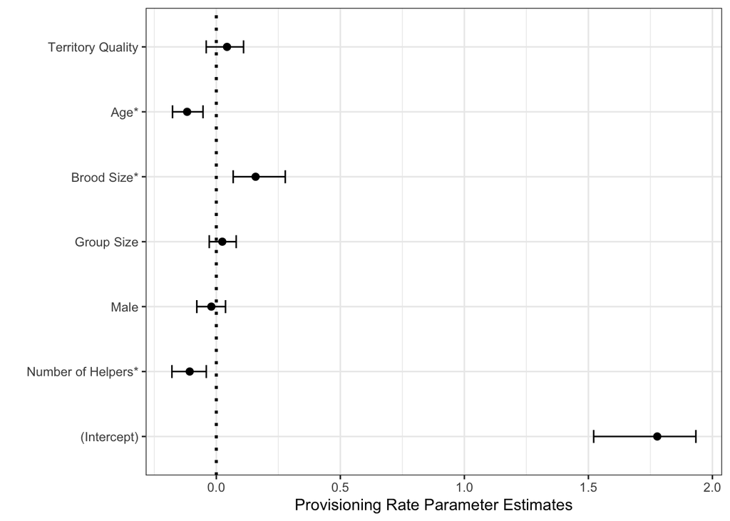

```r
FixedEffects %>%
  ggplot(aes(y = term, x = estimate)) +
  theme_bw() +
  geom_point(size = 2) +
  geom_errorbar(aes(xmin = lower, xmax = upper), width = 0.2) +
  geom_vline(xintercept=c(0), linetype="dotted", size = 1) + xlab("Provisioning Rate Parameter Estimates") + ylab("")
```